# **2. Limpieza de Datos**

## **2.1. Identificación de datos faltantes**

Para comenzar la limpieza de datos en primer lugar debemos ver si existen datos faltantes, y en este caso escribir un código que permita reemplazar la nomenclatura que trae por `NA` que es como R lee los datos faltantes.

Esto puede realizarse cuando importamos el dataset o podemos hacerlo una vez que ya lo tenemos importado. Vemos las dos formas.

**Primera forma (es mucho más simple)**

En este caso dentro del propio código de importación incorporamos un fragmento que nos permite identificar palabras o espacios como datos faltantes, es decir `NA.`

```r
library(readxl)
library(dplyr)
```

```r
# Establecer el na argumento para datos faltantes

ira <- read_excel("IRA.xlsx", na = "*sin dato*")
```

**Segunda forma (una vez importado el dataset)**

Otra forma de realizarlo es una vez que tenemos el dataset incorporado realizarlo con la función `mutate()` del paquete `dplyr`

**Importante:** Hay que tener en cuenta que en nuestro dataset tendremos columnas con distintas estructuras de datos como: caracter, número o fechas. Pero como R no soporta más de una estructura por columna para importar nuestro archivo nos convirtió las fechas y números en formato caracter, ya que en ellas se encontraba el valor: *sin dato*.

Por lo cual necesitaremos primero convertir *sin datos* por NA y luego transformar su estructura en fechas y números nuevamente.

Importamos el dataset sin incorporar en el fragmento de código los `NA:`

```r
ira2 <- read_excel("IRA.xlsx")
```

En este ejemplo veremos de cambiar en primer lugar todas las columnas de caracter con el NA:

```r
#  Reemplazar valores específicos con NA en columnas de carácter

ira2_na <- ira2 %>%
  mutate(across(where(is.character), na_if, "*sin dato*"))
```

Cuando usamos `across()` con `mutate()`, estamos diciendo que queremos aplicar una función a todas las columnas del dataset. Aquí, la estamos utilizando para aplicar una transformación a todas las columnas que cumplen con una condición específica (en este caso, las de tipo **carácter**). En este caso, estamos usando **`na_if`** dentro de **`across()`** para reemplazar todas las apariciones de **`"*sin dato*"`** en columnas de texto por **`NA.`**

*“Para cada valor en las columnas, reemplaza `sin datos` por `NA`.”*

## **2.2. Trabajo con fechas**

Como vimos anteriormente comprender la estructura de datos que tiene nuestro dataset es muy importante para poder manipularlos y administarlos. Por ello vamos a ver como trabajar específicamente con fechas.

### 2.2.1. Conversión de estructuras

En R, hay dos tipos de vectores diferentes que podemos usar para almacenar y trabajar con fechas:

- **`date`** vectores para trabajar con valores de fecha, ejemplo: `2009-01-08`.
- **`POSIXct`**para trabajar con valores de fecha y hora, ejemplo: `2009-01-08 20:00:00`.

**En general, es recomendable trabajar con valores de fecha**, en lugar de valores de fecha y hora, siempre que sea posible.

**Revisión de datos**

En los dataset importados las columnas de “Fecha de toma de muestra” y “Fecha de estudio” se importaron con una estructura de caracter (ya que la información “sin dato” provocó que R leyera como caracter toda la columna).

- **Como Excel guarda las fechas**: Cuando importamos datos de Excel a R y las fechas están en formato de texto con valores como “sin datos”, R puede interpretar esas fechas como números, especialmente si Excel las guarda como números seriales (que es un formato común para fechas en Excel). El número que aperece con este corresponde a la cantidad de días transcurridos desde el **1** **de enero de 1900 (formato predeterminado de Excel para las fechas).**

  Para convertir estos números de serie de Excel a fechas en R, se puede utilizar `as.Date()` con la opción `origin = "1899-12-30".` Este “origen” se debe a que Excel considera el día 1 como el 1 de enero de 1900, pero hay un ajuste de 1 día debido a un error histórico en Excel.
- **Como R guarda las fechas**: R almacena las fechas como números. En concreto, la cantidad de días antes o después del **1 de enero de 1970 a las 00:00:00 UTC.**

Esto es simplemente por si aparecen números que no comprendemos de donde vienen en las columnas fechas. Pero los vamos a trabajar de la misma manera:

Utilizar la funcion `mutate()` para modificar las columnas necesarias a fechas con `as.Date`

```r
ira2_fechas <- ira2_na %>%
  mutate(across(c("Fecha de toma de muestra", "Fecha estudio"),
                ~ as.Date(as.numeric(.), origin = "1899-12-30")))
```

Este código toma las columnas **`"Fecha de toma de muestra"`** y **`"Fecha estudio"`** de un dataset, y las convierte en fechas reales a partir de números que representan días desde una fecha base (en este caso, **1 de enero de 1900**, como ocurre en Excel). Primero, las columnas son convertidas a **números** con **`as.numeric()`**, para asegurar que los valores sean tratados como datos numéricos y no como texto. Luego, **`as.Date()`** convierte esos números en fechas, utilizando la fecha de origen **“1899-12-30”**, que es el estándar para la conversión de fechas en Excel. De esta forma, los valores numéricos son transformados correctamente en fechas reconocidas por R.

### 2.2.1. Conversión de POSIXct a date

Ahora veremos como covertir datos POSIXct a date para una majeor manipulación de los mismos.

```r
# Coversión de POSIXCT  a date

ira2_fechas$`Fecha Nacimiento` <- as.Date(ira2_fechas$`Fecha Nacimiento`)

ira2_fechas$`Fecha Apertura` <- as.Date(ira2_fechas$`Fecha Apertura`)
```

Este código toma la columna **`Fecha Nacimiento`** del `data frame` **`ira2_fechas`** y convierte los valores de esa columna al formato de **fecha** (`Date`) utilizando la función **`as.Date()`**. Lo que hace es sobrescribir los valores actuales de **`Fecha Nacimiento`** con los nuevos valores ya convertidos en formato de fecha.

O es lo mismo que usar la función **`mutate()`** que vimos anteriormente:

```r
# Coversión de POSIXCT  a date

library(dplyr)

ira2_fechas <- ira2_fechas %>%
  mutate(across(c(`Fecha Nacimiento`, `Fecha Apertura`), as.Date))
```

Comprobamos que se realizó la modificación

```r
sapply(ira2_fechas, class)
```

[output not shown]

### 2.2.3. Conversión de formato de fecha

Tambien puedo querer **cambiar el formato de fecha**, por ejemplo si tengo un valor de fecha como 21/10/2024

```r
fecha <- as.Date("2024-10-21")

fecha <- format(fecha, format = "%d/%m/%Y")
```

O si tengo en una columna de mi dataset

```r
ira2_fechas <- ira2_fechas %>%
  mutate(`Fecha Apertura` = format(`Fecha Apertura`, format = "%d/%m/%Y"))
```

#### Ejemplos de formatos de fechas:

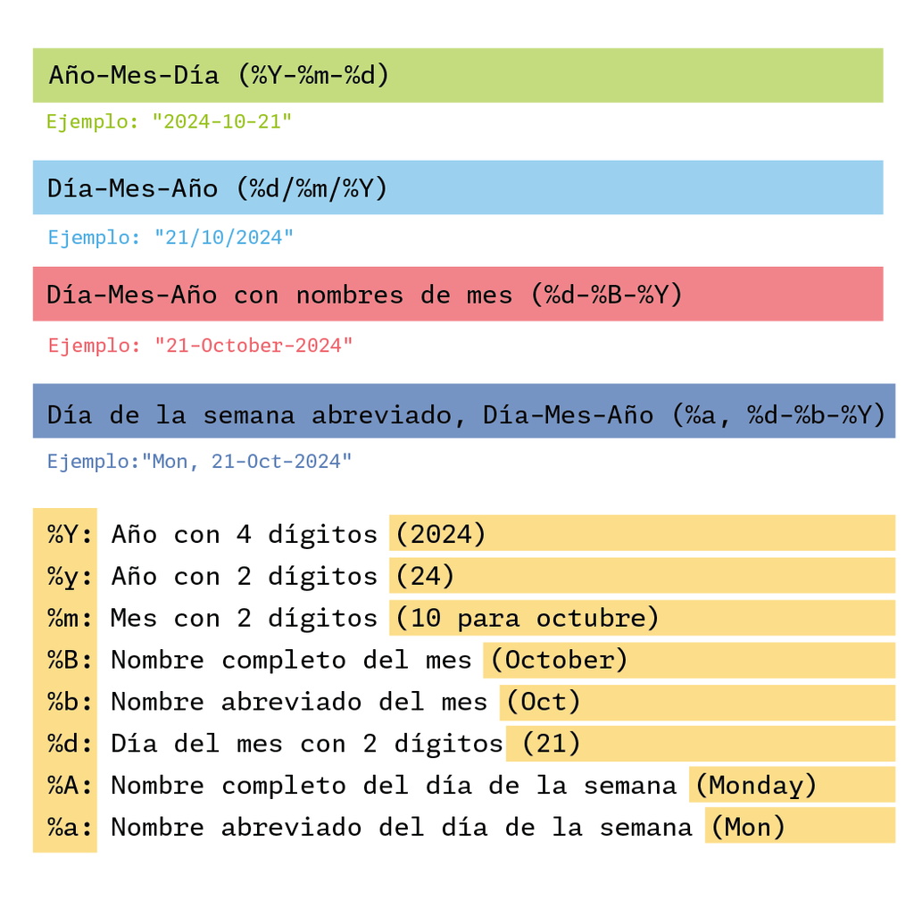

**Algunas fechas incorporadas en R**

**`Sys.Date()`**: Devuelve la fecha actual en formato **`Date`**.

```r
Sys.Date()
```

```
[1] "2024-10-22"
```

## **2.3. Normalización de caracteres**

### 2.3.1. Modificación de minúsculas y mayúsculas

```r
# Pasar todo a mayúsculas

ira <- ira %>%
  mutate(across(where(is.character), toupper))
```

```r
# Pasar todo a minúscula

ira <- ira %>%
  mutate(across(where(is.character), tolower))
```

### 2.3.2. Quitar espacios en blanco

```r
# Sacar espacios en blanco

# ira <- ira %>%
#   mutate(across(where(is.character), str_squish))
```

### 2.3.3. Quitar acentos

```r
# Sacar acentos

# ira <- ira %>%
#   mutate(across(where(is.character), ~ stri_trans_general(., "Latin-ASCII")))
```

Ejemplo con las tres modificaciones en un mismo código:

```r
library(stringr)
library(stringi)

# Ejemplo de una palabra con espacios y acentos
palabra <- " Ángela "

# Transformar la palabra: a mayúsculas, eliminar espacios y quitar acentos
palabra_limpia <- toupper(str_trim(stri_trans_general(palabra, "Latin-ASCII")))

# Ver el resultado
print(palabra_limpia)
```

```
[1] "ANGELA"
```

Antes de guardar y cerrar nuestro archivo es necesario que guardemos nuestro nuevo marcos de datos con el que estuvimos trabajando para que no se pierdan los procesos anteriores con la función `write_xlsx()`

# **3. Guardar el DataFrame**

Guardar los datos en formato `.xlsx` es una buena opción si lo que se busca es preservar la estructura de datos después de la limpieza y además no queremos repetir el proceso en un nuevo proyecto. Se puede guardar un dataframe en un archivo `.xlsx` usando el paquete `writexl.`

```r
# install.packages("writexl")
```

```r
library(writexl)
```

```r
# Guardar y especificar el nuevo nombre de archivo

write_xlsx(ira, path = "ira.xlsx")
```

Ahora podemos comprobar en que directorio estamos trabajando con este comando:

```r
# Quitar el numeral para correr el código

# getwd()
```

Tambien se puede guardar directamente en una ruta específica:

```r
# Guardar en una ruta específica

# write_xlsx(ira, path = "C:/cursor_2024/VigilanciaenR/ira.xlsx")
```